### Modelo compartimentalizado para covid-19 en México

En este modelo la población total (N = 100 000 personas) puede estar en una de 5 categorías o compartimentos (S,E,I,R,D).

- **S**) es la proporción de la población de personas que son suceptibles a estar expuestos e infectarse.
- **E**) es la proporción de la población asintomática-infecciosa, de personas expuesta al virus (beta* S * I), que no manifiestan la enfermedad e infectan a los suceptibles (delta * S * E). Las personas asintomaticas-infecciosas desarrollan los sintomas de covid-19 a una tasa c * E.
- **I**) la proporción de personas enfermas-infecciosas, que manifiestan los síntomas e infectan a los suceptibles. Las personas infecciosas se recuperan a una tasa gamma, y algunos mueren a una tasa (letalidad).
- **R**) la proporcion de la población que se ha recuperado de la enfermedad.
- **D**) la proporción de la población que ha fallecido por la enfermedad (decesos).

El modelo considera las siguientes relaciones entre los compartimentos, desctritas en un sistema de ecuaciones:

```r
library(deSolve)

seird <- function(time, state, parameters) {

  with(as.list(c(state, parameters)), {

    dS <- -beta * S * I - delta * S * E
    dE <-  beta * S * I - c * E + delta * S * E
    dI <-  c*E - gamma * I - letalidad * I
    dR <- gamma * I - letalidad * I
    dD <- letalidad * I

    return(list(c(dS, dE, dI, dR, dD)))
  })
}
```

##### Determinar las condiciones iniciales de la población

En el caso de la epidemia, consideraremos que al inicio toda la población es suceptible (S = 1), el 10 % de las personas ha estado expuesta al virus SARS-CoV-2 es asintomático y puede transmitirlo, el 1 % son casos de personas enfermas-infecciosas, y no hay pacientes recuperados ni decesos por covid-19.

##### Determinar los parámetros epidemiológicos

###### **R0, beta y gamma**

Para el caso de covid 19 se considera que el número reproductivo R0 es 3, y es igual a la tasa de transmisión efectiva (beta) dividida entre la tasa de recuperación (gamma). Asi es que aseguramos que beta/gamma = 3.

###### **letalidad**

Actualmente, la letalidad por COVID-19 en México es del 12 % de los casos de enfermos-infecciosos. Así que asumiremos que una doceava parte de cada incremento en c contribuye a los decesos (0.03/12 = 0.0025).

###### **delta**

La tasa a la que las personas expuestas (asintomáticas-infecciosas) infectan a los suceptibles

###### **c**

La tasa a la que las personas expuestas desarrollan síntomas de COVID-19 y se vuelven enfermos-infecciosos.

```r
  # proporciones iniciales de cada compartimento
  init       <- c(S = 1, E = 0.1, I =0.01, R = 0.0, D = 0.0)

  # parametros
  parameters <- c(beta = 0.03, gamma = 0.01, delta=0.03, c=0.02, letalidad=0.0025)

  # Tiempo de la modelación (365 días)
  times      <- seq(0, 365, by = 1)

  # Resolver el sistema de ecuaciones con ode (General Solver for Ordinary Differential Equations)
  out <- ode(y = init, times = times, func = seird, parms = parameters)

  # Hacer uns base de datos (data frame) con la salida
  out <- as.data.frame(out)
```

Figura 1. Trayectoria de las poblaciones de (S) suceptibles, (E) expuestos (asintomáticos-infecciosos), (I) enfermos-infecciosos, (R) recuperados y (D) decesos.

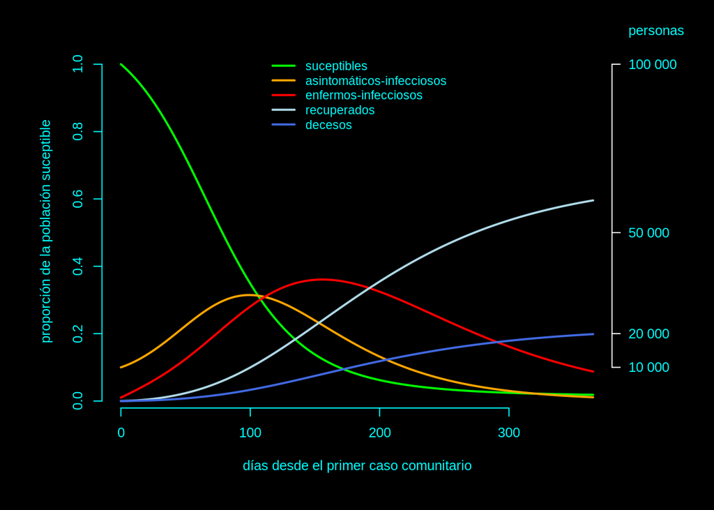

##### Modelo del aislamiento de los infecciosos con sintomas de COVID-19

Podemos cambiar los parámetros epidemiológicos, a condiciones en las que los enfermos por COVID-19 son aislados de los suceptibles al recibir atención médica. Esta medida reduce la tasa efectiva de contagio de los enfermos-infecciosos (beta) en un 50% (de 0.03 a 0.015).

```r
  # proporciones iniciales de cada compartimento
  init       <- c(S = 1, E = 0.1, I =0.01, R = 0.0, D = 0.0)

  # parametros
  parameters2 <- c(beta = 0.015, gamma = 0.01, delta=0.03, c=0.02, letalidad=0.0025)

  ## Definir el tiempo de la modelación (365 días)
  times      <- seq(0, 365, by = 1)

  # Resolver el sistema de ecuaciones con ode (General Solver for Ordinary Differential Equations)
  out2 <- ode(y = init, times = times, func = seird, parms = parameters2)

  # Hacer uns base de datos (data frame) con la salida
  out2 <- as.data.frame(out2)
```

Figura 2. Modelo del aislamiento de los infecsiosos con sintomas de COVID-19 (reducir beta). En el modelo asumimos que no hay una reducción en la infección de suceptibles por los casos asintomáticos (delta). Las infecciones por asintomáticos son la principal fuente de infección en la epídemia.

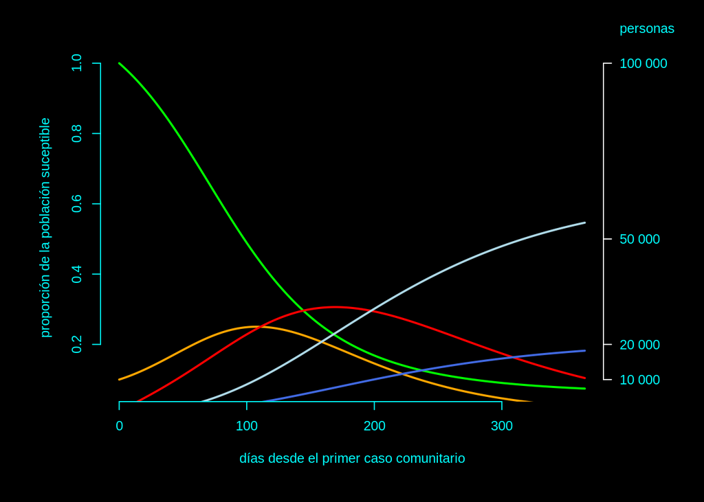